# Étude sur l’évolution des températures moyennes annuelles de la métropole Française

13/05/2024

Groupe 11 ; FISA2025 ; EIGSI La Rochelle

# Groupe de projet 11

- LABORDE Julian
- FAUVEL Adrien
- RIGAUD Anthony
- MASIERO Loric

# Source et données

Pour cette étude nous avons sélectionné les données de météo France donnant la température moyenne par mois de chaque département en France depuis 1951 à 2022.

- Météo-France :  
  [data.gouv.fr](https://www.data.gouv.fr/fr/organizations/meteo-france/)
- Lien vers les données utilisées :  
  [Google Drive](https://drive.google.com/drive/folders/1xliEO8yiK0Znl5TelZTOK7N4B9Mxu71e?usp=sharing)
- Données utilisées :
  - Température (°c)
  - Latitude
  - Longitude
  - Altitude
  - n° de département
  - Nom du département
  - Année
  - Mois
  - Code de la station météorologique

# Mise en Contexte

L’augmentation des températures en France, conséquence du changement climatique, transforme progressivement la vie quotidienne des citoyens. Les vagues de chaleur deviennent plus fréquentes et plus intenses, entraînant des conséquences néfastes sur la santé, notamment pour les populations vulnérables telles que les personnes âgées et les enfants. Les épisodes de canicule compromettent également la productivité économique, avec des perturbations dans divers secteurs tels que l’agriculture, le tourisme et la construction.

Parallèlement, les précipitations deviennent plus imprévisibles, alternant entre des périodes de sécheresse et des épisodes de fortes pluies, ce qui peut conduire à des inondations, des glissements de terrain et des pénuries d’eau. Les changements climatiques affectent également la biodiversité, perturbant les écosystèmes naturels et menaçant la flore et la faune locales (feu de forêt, prolifération des moustiques, etc.).

Pour rappel, l’origine du réchauffement climatique est principalement causée par l’augmentation des émissions de CO2 résultant de l’activité humaine, notamment de la combustion des combustibles fossiles tels que le charbon, le pétrole et le gaz naturel.

# Objectifs de l’étude

Dans cette étude, nous souhaitons mettre en avant l’évolution de la température moyenne annuelle dans l’hexagone et l’afficher sur une cartographie facilement lisible. De cette façon, nous vous proposons d’étudier deux cartes représentant les températures recueillies sur 280 stations météorologiques réparties dans le pays. À partir de ces deux cartes, nous pourrons dans un second temps les interpréter et les comparer et enfin en tirer des conclusions factuelles sur l’évolution des températures en France et faire le lien avec le changement climatique.

Les données brutes utilisées dans cette étude proviennent d’une source fiable (Open Data University) et sont dédiées aux études statistiques pour les établissements supérieurs. Les données sont présentées sous forme d’une multitude de fichiers au format CSV qu’il est nécessaire de traiter avec un outil spécifique : R Studio. Celui-ci nous permettra de mettre en forme les données brutes, les visualiser sur un graphique pour enfin les interpréter.

# Interprétations

## Graphe des températures par département

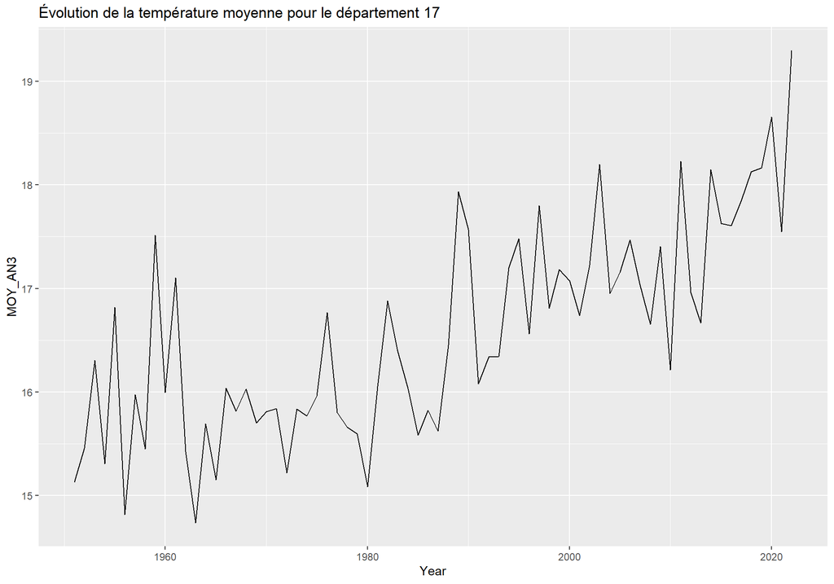

Note : Nous avons décidé de présenter les évolutions de température dans le département de la Charente-Maritime (17), mais il est possible de visualiser les données sur n’importe quel département de France ou les données sources sont disponibles. (Voir Annexes)

[interactive chart not shown]

Nous pouvons observer une tendance à l’augmentation de la température moyenne dans la Charente-Maritime depuis les années 1950. Cette augmentation s’inscrit dans le cadre plus large du réchauffement climatique mondial, résultant en grande partie des activités humaines émettrices de gaz à effet de serre (transport, industrie, résidentiel etc.).

Il est important de noter que l’augmentation de la température moyenne a des implications diverses et souvent complexes pour la région, notamment en ce qui concerne la biodiversité ou l’agriculture avec des sécheresses ou bien des précipitations excessives qui sature les sols en eau (exemple de la météo actuelle).

## Moyenne des températures par année

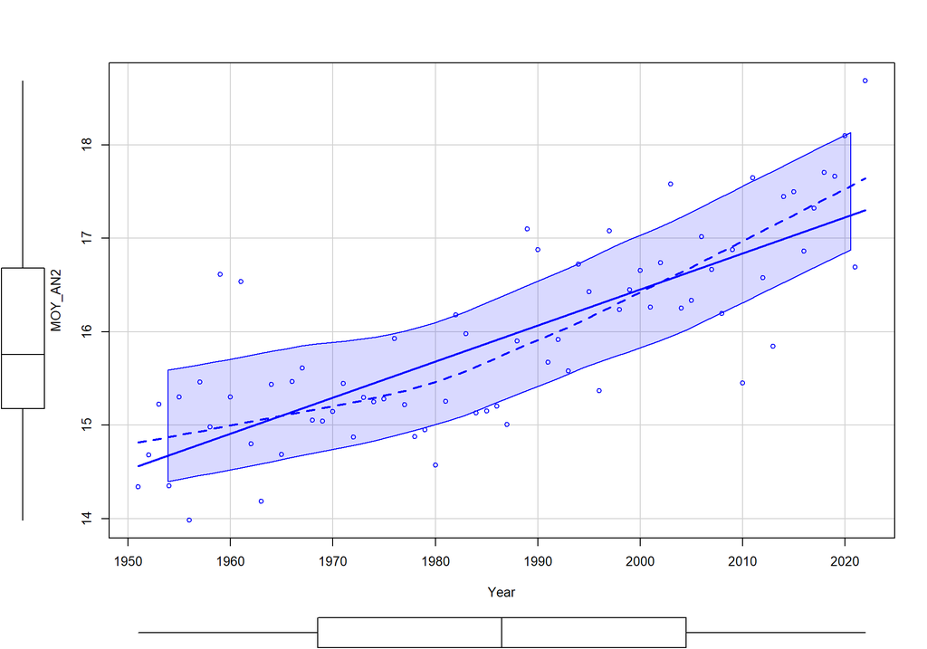

Grâce à ce second graphique, nous avons la possibilité de visualiser les températures moyennes par année mais cette fois-ci à une échelle plus large : la France métropolitaine. Chaque point représente une température moyenne annuelle. Comme les données sont nombreuses, une courbe de tendance est tracée. On constate que cette courbe est presque linéaire et sa pente augmente progressivement depuis quelques années, formant une parabole. On peut interpréter cela par une augmentation des températures qui s’accélère avec le stockage des gaz à effet de serre (GES) dans l’atmosphère. En effet, il faut rappeler que le CO2 à une durée de vie de plusieurs centaines d’années et donc que les GES s’accumulent accentuant l’effet de serre.

Nous pouvons tout de même constater que certaines années sont plus chaudes que les autres et ce depuis bien longtemps (exemple avec deux années très chaudes avant et après 1960). Enfin, nous pouvons grossièrement estimer la hausse des températures depuis 1950. Avec une température moyenne d’environ 15°C en 1950 et d’environ 17,5 °C en 2020, soit une augmentation de + 2,5 °C. À ce stade-là, nous pouvons nous demander si nous pouvons réellement respecter nos objectifs fixés pour 2050 avec une limitation de +2°C.

## Carte des températures moyenne en France 1951-2022 (intéractive)

[interactive chart not shown]

Note : il est possible de faire varier le curseur pour visualiser les températures moyennes par année depuis 1951 jusqu’à 2022. Le dégradé de couleur permet aussi de faciliter la compréhension avec des températures moyennes plus élevées lorsque le ton se rapproche du orange foncé (et inversement).

L’évolution de la température à l’échelle de la France a également des tendances similaires à celles observées dans la Charente-Maritime et dans le monde entier. Depuis 1950, la température moyenne en France a augmenté de manière significative.

En ce qui concerne les zones les plus impactées par cette augmentation de la température, on observe généralement une tendance à des augmentations plus prononcées dans les régions du sud de la France, notamment dans le Sud-Est (cf shinyApp), le Sud-Ouest et certaines parties de la Méditerranée. Ces régions sont souvent caractérisées par des climats plus chauds et plus secs, ce qui rend leur sensibilité au réchauffement climatique plus élevée. Ces données sont cohérentes avec les propos du GIEC qui avait prédit il y a déjà plusieurs années un réchauffement particulièrement important pour le bassin méditerranéen.

Malgré que les régions du Nord semblent rester plus fraîches avec le dégradé de couleur (qui permet de facilement visualiser les tendances des températures sur tout le territoire), le changement climatique à également de forts impacts sur ces départements avec par exemple l’augmentation des catastrophes naturelles en particulier les inondations importantes (inondations de 2024). Au sud, les événements extrêmes se manifestent davantage par des feux de forêt (exemple des feux de forêt en gironde en été 2022).

# Conclusion

Les données visualisées dans cette étude sont sans appel : les températures moyennes dans l’hexagone ont augmenté. Au vu du gradient de température, il est évident que l‘action humaine, en plus du réchauffement naturel cyclique de notre planète, est la principale cause de cette hausse des températures. À noter que les données interprétées sont des valeurs moyennes et que les températures maximales atteignent elles aussi des records chaque année, avec de lourdes conséquences sur l’environnement et la santé humaine. Nous pouvons donc conclure qu’il est nécessaire de changer nos habitudes afin de réduire nos émissions de CO2 : moins de vol en avion, utilisation des transports en commun, réduction de l’alimentation carnée etc.).

# Annexes

### Graphe de l’ensemble des températures par département

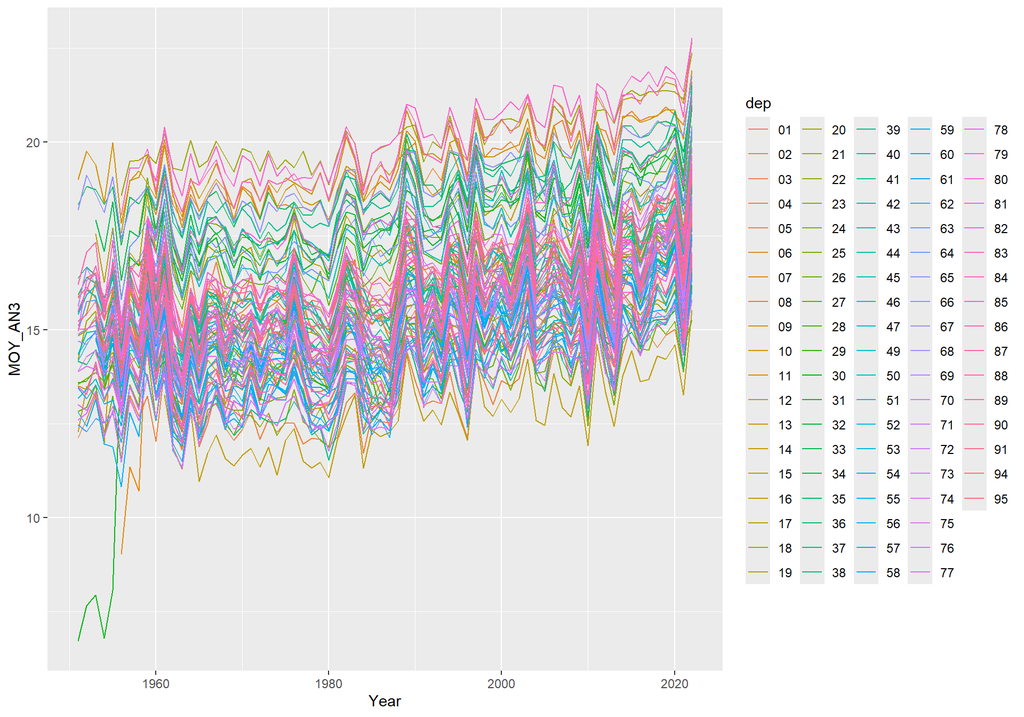

- Code Rmarkdown avec ShinyApp [RMD avec Shiny](https://drive.google.com/drive/folders/1gABajKfoVAm24aJpiiswY90cwLaVOhhb?usp=sharing)